# Restricted and Protected Plant Species in India

Wildlife Protection Act Schedule VI, Biological Diversity Act, and CITES — A Comprehensive Reference

Kwiz Research

07 April 2026

# Executive Summary

India is one of the world’s **17 megadiverse** countries, hosting approximately **47,513 plant species** — representing about 11% of global flora — across 4 recognised biodiversity hotspots (Himalaya, Western Ghats, Indo-Burma, Sundaland). The country’s flora includes numerous species of global conservation significance that are simultaneously under severe collection and trade pressure.

# 1 Legal Framework

## 1.1 Wild Life (Protection) Act, 1972 — Schedule VI

The **Wild Life (Protection) Act, 1972** (WLPA) — as comprehensively amended by the Wild Life (Protection) Amendment Act 2022 — is India’s primary wildlife legislation. **Schedule VI** lists **“Specified Plants”** for which collection, uprooting, damage, trade, and possession are prohibited without a licence from the Chief Wildlife Warden of the relevant state.

Key provisions: - **Section 17A:** No person shall uproot, damage, collect, acquire or possess any Scheduled plant (other than for personal possession/cultivation without trade intent). - **Section 17C:** No person shall deal in, sell, or offer for sale any Scheduled plant or its derivative without a licence. - **Section 51 (penalties):** For Schedule VI violations: imprisonment up to **3 years** and/or fine up to **₹25,000** (enhanced by 2022 Amendment). - **Section 49B:** Import of Scheduled species requires CITES documentation and permission of Director General of Foreign Trade.

The **2022 Amendment** reorganised the Schedule system (from VI Schedules to IV), consolidating some provisions. Schedule VI equivalent species are now in the new Schedule structure.

Full text: [IndiaCode — WPA 1972](https://www.indiacode.nic.in/bitstream/123456789/1726/2/A1972-53.pdf)

**⚠ Implementation Gap** — Schedule VI lists only approximately **29 species/genera** explicitly. Given India’s 47,000+ plant species, this coverage is extremely narrow. The Botanical Survey of India (BSI) has assessed hundreds of additional species as threatened, but these lack Schedule VI protection. The Ministry of Environment, Forest and Climate Change (MoEFCC) has not comprehensively updated the Schedule VI list since the original enactment despite documented declines in many medicinal and horticultural plant species.

## 1.2 Biological Diversity Act, 2002

The **Biological Diversity Act, 2002** (Act No. 18 of 2003) implements the Convention on Biological Diversity (CBD) and the Nagoya Protocol. It establishes the National Biodiversity Authority (NBA) to regulate: - **Access to Biological Resources:** Any person seeking to obtain biological resources for commercial use must obtain prior approval from the NBA (foreigners/foreign entities) or file intimation with State Biodiversity Boards (Indians). - **Benefit Sharing:** Commercial use of biological resources must be accompanied by benefit sharing with local communities and knowledge holders. - **Biodiversity Management Committees (BMCs):** Gram Panchayats and urban local bodies must establish BMCs and maintain People’s Biodiversity Registers (PBRs).

The **Biological Diversity (Amendment) Act, 2023** made significant changes, exempting traditional practitioners and cultivators from ABS requirements and simplifying the research pathway.

Full text: [WIPO Lex — Biological Diversity Act 2002](https://www.wipo.int/wipolex/en/legislation/details/6058)

## 1.3 Environment (Protection) Act, 1986

The **Environment (Protection) Act, 1986** (EPA) provides a framework for Central Government notifications covering invasive species and specific environmental restrictions. Several State Pollution Control Boards have issued orders under EPA for control of major invasive plants such as *Parthenium hysterophorus* and *Eichhornia crassipes*.

## 1.4 CITES Implementation in India

Key CITES-listed Indian plant groups: - All Orchidaceae (Appendix II; *Paphiopedilum* spp. Appendix I) - All Cycadaceae (Appendix I/II) - *Taxus* spp. (Himalayan yew) — Appendix II - *Dioscorea deltoidea* — Appendix II - *Pterocarpus santalinus* (Red Sanders) — Appendix II - *Saussurea costus* (Kuth) — Appendix I

# 2 Regional / Subnational Restrictions

India’s constitutional framework gives states concurrent legislative authority over forests and wildlife. Each state has a **Chief Wildlife Warden** (CWW) who administers the Wild Life (Protection) Act, a **State Biodiversity Board (SBB)** under the Biological Diversity Act, and a **State Forest Department** with its own rules for forest produce collection. Many states impose restrictions *beyond* the WPA Schedule VI list, particularly for commercially valuable medicinal plants and timber trees.

## 2.1 State Biodiversity Boards (SBBs) — Biological Diversity Act, 2002

Each of India’s 28 states and 8 Union Territories has a **State Biodiversity Board** constituted under the BDA. SBBs regulate commercial access to biological resources within the state. Specific state-level restrictions include:

[output not shown]

## 2.2 Chief Wildlife Warden Permits — State-Level Licensing

For WPA Schedule VI species, **state CWW permits** are required for: - Collection for bona fide scientific research - Cultivation under CITES documentation - Export/import for approved purposes

CWW permit authority means enforcement is **state-specific**: a permit from Karnataka does not cover collection in Himachal Pradesh for the same species. This creates significant inter-state trade regulatory complexity.

## 2.3 People’s Biodiversity Registers (PBRs) — Village-Level Restrictions

Under BDA Section 41, Gram Panchayats and urban local bodies must establish **Biodiversity Management Committees (BMCs)** and maintain **People’s Biodiversity Registers (PBRs)** documenting local biological resources. BMCs may levy a **benefit-sharing charge** on commercial users of locally documented resources. Several states (Kerala, Karnataka, Sikkim) have advanced PBR frameworks with >1,000 registers documented that effectively create village-level species access controls.

**Source note** — State SBB portals: [NBA India — State Biodiversity Boards](https://www.nbaindia.org/state-bdb.html) | Karnataka KFD: kfd.gov.in | Uttarakhand Medicinal Plant Board: umb.uk.gov.in | Kerala KMPB: kmpb.kerala.gov.in.

# 3 Regulatory Institutions

Table 1. Institutions with Plant Regulatory Mandates in India

| Abbrev. | Institution | Ministry | Mandate |
| --- | --- | --- | --- |
| MoEFCC | Ministry of Environment, Forest and Climate Change | GoI | Central regulator; WPA administration; CITES authority; NBA oversight |
| WCCB | Wildlife Crime Control Bureau | MoEFCC | Central intelligence and enforcement; coordinates interstate WPA/CITES cases |
| BSI | Botanical Survey of India | MoEFCC | Botanical inventory; Red List assessments; flora of India; Schedule VI science |
| NBA | National Biodiversity Authority | MoEFCC | ABS regulation; bioprospecting approvals; Nagoya Protocol implementation |
| Forest Dept | State Forest Departments (28 states + 8 UTs) | State Govts | WPA enforcement; Chief Wildlife Wardens; TOPS permits; reserved forest management |
| NBWL | National Board for Wildlife | MoEFCC | Policy oversight; protected area management; species conservation plans |
| FSI | Forest Survey of India | MoEFCC | National forest inventory; remote sensing; forest cover mapping |
| ICAR | Indian Council of Agricultural Research | DARE | Invasive species research; plant protection; crop pest and weed management |

# 4 Comprehensive Plant Species Listing

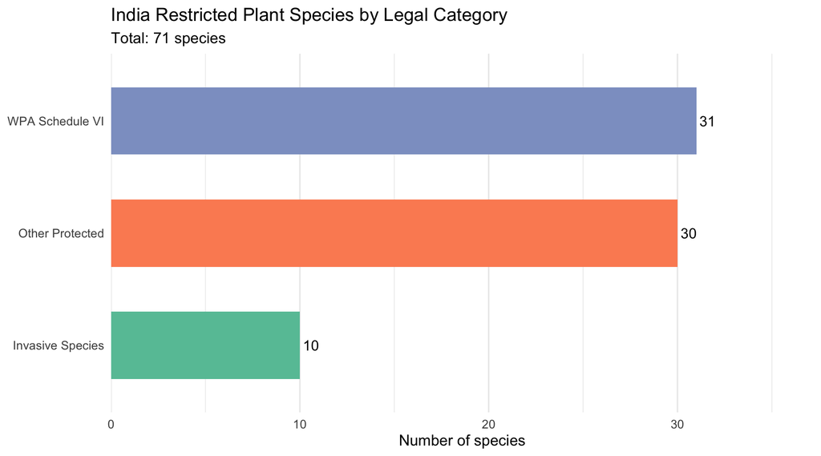

India restricted plant species by legal category.

## 4.1 Master Species Table

Table 2. Restricted/Protected Plant Species in India

| Common Name | Scientific Name | Group | IUCN | CITES | India Legal Status | Managing Inst. | Notes |
| --- | --- | --- | --- | --- | --- | --- | --- |
| Ashwagandha (wild) | *Withania somnifera* | Magnoliopsida | Least Concern | Not listed | BD Act <u+2014> ABS regulated </u+2014> | NBA / State SBBs | Key ayurvedic adaptogen; wild populations declining; now mostly cultivated |
| Bael / Wood apple | *Aegle marmelos* | Magnoliopsida | Least Concern | Not listed | BD Act <u+2014> ABS regulated </u+2014> | NBA / State SBBs | Sacred tree; Shiva worship; medicinal fruit; wild harvest monitored |
| Brahmi | *Bacopa monnieri* | Magnoliopsida | Least Concern | Not listed | BD Act <u+2014> ABS regulated </u+2014> | NBA / State SBBs | Memory-enhancing herb; international supplement trade; wetland species |
| Guduchi / Giloy | *Tinospora cordifolia* | Magnoliopsida | Least Concern | Not listed | BD Act <u+2014> ABS regulated </u+2014> | NBA / State SBBs | Ayurvedic immunomodulator; demand surged during COVID-19; wild harvest concerns |
| Isabgol / Psyllium | *Plantago ovata* | Magnoliopsida | Least Concern | Not listed | BD Act <u+2014> ABS for wild genetic resources </u+2014> | NBA / ICAR | Wild relatives in Rajasthan/Gujarat; cultivated commercially; ABS for genetics |
| Safed Musli | *Chlorophytum borivilianum* | Magnoliopsida | Least Concern | Not listed | BD Act <u+2014> ABS regulated </u+2014> | NBA / State SBBs | Tuberous aphrodisiac herb; wild populations severely depleted; now cultivated |
| Shankhpushpi | *Convolvulus prostratus* | Magnoliopsida | Least Concern | Not listed | BD Act <u+2014> ABS regulated </u+2014> | NBA / State SBBs | Brain tonic herb; grassland species; commercial ayurvedic demand |
| Shatavari | *Asparagus racemosus* | Magnoliopsida | Least Concern | Not listed | BD Act <u+2014> ABS regulated </u+2014> | NBA / State SBBs | Ayurvedic tonic; root over-harvest; declining wild populations across India |
| Tulsi / Holy basil | *Ocimum tenuiflorum* | Magnoliopsida | Least Concern | Not listed | BD Act <u+2014> ABS regulated </u+2014> | NBA / State SBBs | Sacred medicinal herb; commercial supplement industry; ABS required for export |
| Guggul | *Commiphora wightii* | Magnoliopsida | Critically Endangered | Not listed | BD Act <u+2014> ABS regulated / State protected </u+2014> | NBA / Rajasthan FD | Oleo-gum resin for cholesterol; CR; Rajasthan/Gujarat arid zone; over-tapped |
| Amla / Indian gooseberry | *Phyllanthus emblica* | Magnoliopsida | Least Concern | Not listed | BD Act <u+2014> ABS regulated / Forest produce </u+2014> | NBA / State FDs | Key ayurvedic fruit; NTFP under forest law; commercial ABS applies |
| Arjun tree | *Terminalia arjuna* | Magnoliopsida | Least Concern | Not listed | BD Act <u+2014> ABS regulated </u+2014> | NBA / State FDs | Cardiotonic bark; heavily harvested for herbal medicine; riverbank species |
| Aerides multiflora | *Aerides multiflora* | Magnoliopsida | Least Concern | Appendix II | CITES App. II | MoEFCC / WCCB | Fox-brush orchid; W Ghats and NE India; epiphytic; local trade |
| Bulbophyllum leopardinum | *Bulbophyllum leopardinum* | Magnoliopsida | Least Concern | Appendix II | CITES App. II | MoEFCC / WCCB | Himalayan mini-orchid; Sikkim/Arunachal; all Orchidaceae CITES II |
| Coelogyne cristata | *Coelogyne cristata* | Magnoliopsida | Least Concern | Appendix II | CITES App. II | MoEFCC / WCCB | Angel orchid; Himalayan epiphyte; popular in horticulture; mass-collected |
| Cymbidium devonianum | *Cymbidium devonianum* | Magnoliopsida | Least Concern | Appendix II | CITES App. II | MoEFCC / WCCB | NE India pendant cymbidium; popular orchid; wild collection pressure |
| Dendrobium nobile | *Dendrobium nobile* | Magnoliopsida | Least Concern | Appendix II | CITES App. II | MoEFCC / WCCB | Noble dendrobium; NE India; TCM ingredient; heavily traded from Himalayan forests |
| Phalaenopsis taenialis | *Phalaenopsis taenialis* | Magnoliopsida | Least Concern | Appendix II | CITES App. II | MoEFCC / WCCB | Himalayan Phalaenopsis; deciduous; winter-flowering; collection pressure |
| Pleione praecox | *Pleione praecox* | Magnoliopsida | Least Concern | Appendix II | CITES App. II | MoEFCC / WCCB | Peacock orchid; NE India; autumn-flowering alpine; horticultural demand |
| Thunia alba | *Thunia alba* | Magnoliopsida | Least Concern | Appendix II | CITES App. II | MoEFCC / WCCB | White thunia; Himalayan terrestrial orchid; traded for gardens |
| Sissoo / Dalbergia melanoxylon (India range) | *Dalbergia melanoxylon* | Magnoliopsida | Near Threatened | Appendix II | CITES App. II | MoEFCC / WCCB | African blackwood also in Indian trade; all Dalbergia CITES II |
| Rhynchostylis retusa | *Rhynchostylis retusa* | Magnoliopsida | Least Concern | Appendix II | CITES App. II / State flower Assam | MoEFCC / WCCB / Assam FD | Foxtail orchid; state flower of Assam/Arunachal; festival use (Bihu) |
| Indian rosewood / Malabar | *Dalbergia latifolia* | Magnoliopsida | Vulnerable | Appendix II | CITES App. II / State Protected | State FDs / WCCB | Premium furniture timber; South Indian species; CITES II |
| Shisham / Indian rosewood | *Dalbergia sissoo* | Magnoliopsida | Least Concern | Appendix II | CITES App. II (all Dalbergia) | State FDs / WCCB | All Dalbergia CITES II since 2017; major timber; wilt disease devastating plantations |
| Agarwood (Indian) | *Aquilaria malaccensis* | Magnoliopsida | Critically Endangered | Appendix II | CITES App. II <u+2014> Export regulated </u+2014> | MoEFCC / WCCB | Resinous heartwood for oud perfume; NE India; massively over-harvested |
| Orchid tree / Paphiopedilum hirsutissimum | *Paphiopedilum hirsutissimum* | Magnoliopsida | Vulnerable | Appendix I | CITES App. I | MoEFCC / WCCB | NE India/SE Asia; large-flowered slipper orchid; smuggling for collectors |
| Mesquite / Vilayati babool | *Prosopis glandulosa* | Magnoliopsida | Least Concern | Not listed | Invasive <u+2014> arid zone </u+2014> | CAZRI / State FDs | Dryland invasive hybridising with P. juliflora; Northern India spread |
| Prosopis (mesquite) | *Prosopis juliflora* | Magnoliopsida | Least Concern | Not listed | Invasive <u+2014> semi-arid degradation </u+2014> | MoEFCC / CAZRI | Semi-arid invasive; massive spread in Rajasthan, Gujarat, Tamil Nadu; >5M ha |
| Salvinia (giant) | *Salvinia molesta* | Magnoliopsida | Least Concern | Not listed | Invasive <u+2014> aquatic weed </u+2014> | State PCBs / ICAR | Giant floating fern; smothers Kerala backwaters; biological control deployed |
| Water hyacinth | *Eichhornia crassipes* | Magnoliopsida | Least Concern | Not listed | Notified Invasive Species | MoEFCC / State PCBs | Major freshwater invasive; covers millions of ha; hydropower threat |
| Indian sandalwood | *Santalum album* | Magnoliopsida | Vulnerable | Appendix II | State Protected Tree / CITES II | State Forest Dept / WCCB | Govt ownership in Karnataka; major illicit trade; CITES II since CoP19 |
| Chromolaena / Siam weed | *Chromolaena odorata* | Magnoliopsida | Least Concern | Not listed | Invasive <u+2014> Western Ghats/NE India </u+2014> | Forest Dept | Fire-promoting invasive shrub; transforms forest understorey; W Ghats |
| Cabomba | *Cabomba caroliniana* | Magnoliopsida | Least Concern | Not listed | Invasive <u+2014> aquarium trade escape </u+2014> | MoEFCC / Plant quarantine | Aquatic weed spreading from aquarium trade; Kerala/Tamil Nadu waterways |
| Khejri / Prosopis cineraria | *Prosopis cineraria* | Magnoliopsida | Least Concern | Not listed | State tree Rajasthan <u+2014> Protected </u+2014> | Rajasthan Forest Dept | Desert keystone; Bishnoi community protection; state tree; felling banned |
| Ageratum / Goat weed | *Ageratum conyzoides* | Magnoliopsida | Least Concern | Not listed | Invasive <u+2014> crop fields </u+2014> | ICAR / State Depts | Pantropical weed; major rice and tea field invader; allelopathic |
| Mimosa (giant sensitive) | *Mimosa diplotricha* | Magnoliopsida | Least Concern | Not listed | Invasive <u+2014> NE India plantation threat </u+2014> | ICAR / State Depts | Thorny scrambler; invades tea gardens and roadsides in NE India |
| Parthenium weed | *Parthenium hysterophorus* | Magnoliopsida | Least Concern | Not listed | Invasive / Noxious Weed | ICAR / State Depts | Widespread invasive; severe human allergy; crop competitor; all states |
| Sal tree | *Shorea robusta* | Magnoliopsida | Least Concern | Not listed | State Protected <u+2014> revenue tree </u+2014> | State Forest Depts | Major timber tree; government-controlled; NTFP (sal leaves/seeds) regulated |
| Teak (natural forests) | *Tectona grandis* | Magnoliopsida | Least Concern | Not listed | State Protected <u+2014> felling restricted </u+2014> | State Forest Depts | Logging from natural forests restricted in most states; plantations regulated |
| Ipomoea carnea | *Ipomoea carnea* | Magnoliopsida | Least Concern | Not listed | Invasive <u+2014> wetland degrader </u+2014> | State PCBs / Forest Dept | Toxic shrub; invades wetlands and wastelands; cattle poisoning |
| Lantana | *Lantana camara* | Magnoliopsida | Least Concern | Not listed | Invasive <u+2014> National Park threat </u+2014> | Forest Dept / Protected Areas | Major forest understory invasive; covers 13M ha; managed in tiger reserves |
| Mikania (mile-a-minute) | *Mikania micrantha* | Magnoliopsida | Least Concern | Not listed | Invasive <u+2014> NE India / Western Ghats </u+2014> | Forest Dept / Tea estates | Smothering climber; invades tea gardens and NE India forests; rapid growth |
| Cycas beddomei | *Cycas beddomei* | Cycadopsida | Critically Endangered | Appendix I | Schedule VI <u+2014> Specified Plant </u+2014> | MoEFCC / WCCB | Endemic to Andhra Pradesh; all Cycas spp. Schedule VI |
| Kuth / Costus root | *Saussurea costus* | Magnoliopsida | Critically Endangered | Appendix I | Schedule VI <u+2014> Specified Plant </u+2014> | MoEFCC / WCCB | Critically threatened; traditional medicine and perfumery; Himalayan |
| Shilajeet plant / Frerea | *Frerea indica* | Magnoliopsida | Critically Endangered | Not listed | Schedule VI <u+2014> Specified Plant </u+2014> | MoEFCC / WCCB | Extremely rare succulent; Junnar, Pune dist.; <50 plants known |
| Slipper orchid (India) | *Paphiopedilum druryi* | Magnoliopsida | Critically Endangered | Appendix I | Schedule VI <u+2014> Specified Plant </u+2014> | MoEFCC / WCCB | Most threatened Indian slipper orchid; Agasthyamalai hills; <100 plants |
| Spikenard / Jatamansi | *Nardostachys jatamansi* | Magnoliopsida | Critically Endangered | Appendix II | Schedule VI <u+2014> Specified Plant </u+2014> | MoEFCC / WCCB | Himalayan aromatic herb; heavily traded for ayurvedic use; CITES II |
| Ativisha / Aconitum | *Aconitum heterophyllum* | Magnoliopsida | Endangered | Not listed | Schedule VI <u+2014> Specified Plant </u+2014> | MoEFCC / WCCB | Himalayan monkshood; ayurvedic Ativisha; anti-fever; extremely rare |
| Blue vanda orchid | *Vanda coerulea* | Magnoliopsida | Endangered | Appendix I | Schedule VI <u+2014> Specified Plant </u+2014> | MoEFCC / WCCB | NE India; heavily collected for horticulture; blue orchid icon |
| Cycas circinalis | *Cycas circinalis* | Cycadopsida | Endangered | Appendix II | Schedule VI <u+2014> Specified Plant </u+2014> | MoEFCC / WCCB | Queen sago; Western Ghats; traditional food plant; habitat loss |
| Himalayan yew | *Taxus wallichiana* | Pinopsida | Endangered | Appendix II | Schedule VI <u+2014> Specified Plant </u+2014> | MoEFCC / WCCB | Source of taxol (cancer treatment); heavily exploited across Himalaya |
| Kutki / Picrorhiza | *Picrorhiza kurrooa* | Magnoliopsida | Endangered | Not listed | Schedule VI <u+2014> Specified Plant </u+2014> | MoEFCC / WCCB | Alpine Himalayan herb; hepatoprotective; massively over-collected |
| Paphiopedilum fairrieanum | *Paphiopedilum fairrieanum* | Magnoliopsida | Endangered | Appendix I | Schedule VI <u+2014> Specified Plant </u+2014> | MoEFCC / WCCB | Himalayan slipper orchid; Sikkim/Arunachal; horticultural demand |
| Paphiopedilum spicerianum | *Paphiopedilum spicerianum* | Magnoliopsida | Endangered | Appendix I | Schedule VI <u+2014> Specified Plant </u+2014> | MoEFCC / WCCB | NE India endemic; Assam/Nagaland/Manipur; smuggling for trade |
| Pitcher plant (Indian) | *Nepenthes khasiana* | Magnoliopsida | Endangered | Appendix II | Schedule VI <u+2014> Specified Plant </u+2014> | MoEFCC / WCCB | Only Nepenthes in India; Meghalaya endemic; carnivorous plant; habitat loss |
| Red Sanders | *Pterocarpus santalinus* | Magnoliopsida | Endangered | Appendix II | Schedule VI <u+2014> Specified Plant </u+2014> | MoEFCC / WCCB / APFD | Most trafficked plant; smuggling to China/SE Asia; Seshachalam hills endemic |
| Cypripedium elegans | *Cypripedium elegans* | Magnoliopsida | Least Concern | Appendix II | Schedule VI <u+2014> Specified Plant </u+2014> | MoEFCC / WCCB | Small Himalayan slipper orchid; Sikkim/Bhutan border forests |
| Cypripedium himalaicum | *Cypripedium himalaicum* | Magnoliopsida | Least Concern | Appendix II | Schedule VI <u+2014> Specified Plant </u+2014> | MoEFCC / WCCB | Himalayan alpine orchid; J&K to Arunachal; high-altitude meadows |
| Dioscorea (medicinal yam) | *Dioscorea deltoidea* | Magnoliopsida | Least Concern | Appendix II | Schedule VI <u+2014> Specified Plant </u+2014> | MoEFCC / WCCB | Source of diosgenin (contraceptive); over-harvested in Himalaya |
| Euphorbia (succulent) | *Euphorbia nivulia* | Magnoliopsida | Least Concern | Appendix II | Schedule VI <u+2014> Specified Plant </u+2014> | MoEFCC / WCCB | Succulent euphorbia; entire genus regulated under CITES |
| Himalayan poppy | *Meconopsis regia* | Magnoliopsida | Least Concern | Not listed | Schedule VI <u+2014> Specified Plant </u+2014> | MoEFCC / WCCB | Alpine poppy; high-altitude endemic; ornamental collection threat |
| Indian marsh orchid | *Dactylorhiza hatagirea* | Magnoliopsida | Least Concern | Appendix II | Schedule VI <u+2014> Specified Plant </u+2014> | MoEFCC / WCCB | Alpine orchid; used in Shilajit preparation; heavy collection pressure |
| Indian serpentine / Rauvolfia | *Rauvolfia serpentina* | Magnoliopsida | Least Concern | Appendix II | Schedule VI <u+2014> Specified Plant </u+2014> | MoEFCC / WCCB | Sedative alkaloid reserpine; over-collected from wild |
| Lady slipper orchid | *Cypripedium cordigerum* | Magnoliopsida | Least Concern | Appendix II | Schedule VI <u+2014> Specified Plant </u+2014> | MoEFCC / WCCB | High-altitude Himalayan orchid; entire genus Schedule VI |
| Ceropegia (India) | *Ceropegia spp.* | Magnoliopsida | Various | Appendix II | Schedule VI <u+2014> Specified Plant </u+2014> | MoEFCC / WCCB | Entire genus listed; several Indian endemics CR/EN; tuberous plants |
| Cycas pectinata | *Cycas pectinata* | Cycadopsida | Vulnerable | Appendix II | Schedule VI <u+2014> Specified Plant </u+2014> | MoEFCC / WCCB | NE India hill cycad; Assam/Meghalaya/Arunachal; forest loss |
| Indian podophyllum | *Podophyllum hexandrum* | Magnoliopsida | Vulnerable | Appendix II | Schedule VI <u+2014> Specified Plant </u+2014> | MoEFCC / WCCB | Source of podophyllotoxin (anti-cancer drug); alpine Himalaya; over-harvested |
| Paphiopedilum insigne | *Paphiopedilum insigne* | Magnoliopsida | Vulnerable | Appendix I | Schedule VI <u+2014> Specified Plant </u+2014> | MoEFCC / WCCB | NE India; Nagaland/Manipur; historically over-collected for European trade |
| Paphiopedilum venustum | *Paphiopedilum venustum* | Magnoliopsida | Vulnerable | Appendix I | Schedule VI <u+2014> Specified Plant </u+2014> | MoEFCC / WCCB | NE India slipper orchid; lowland forests of Assam/Meghalaya |
| Paphiopedilum villosum | *Paphiopedilum villosum* | Magnoliopsida | Vulnerable | Appendix I | Schedule VI <u+2014> Specified Plant </u+2014> | MoEFCC / WCCB | NE India/Myanmar border; sub-montane forests; heavy collection |
| Renanthera imschootiana | *Renanthera imschootiana* | Magnoliopsida | Vulnerable | Appendix II | Schedule VI <u+2014> Specified Plant </u+2014> | MoEFCC / WCCB | Red vanda; NE India/Myanmar; montane forest epiphyte; rare |

## 4.2 Schedule VI — Specified Plants

The Wild Life (Protection) Act Schedule VI lists approximately 29 plant taxa for which collection, trade, and possession without a licence from the Chief Wildlife Warden is prohibited. The list heavily emphasises medicinally and horticulturally significant species facing exploitation pressure.

[output not shown]

## 4.3 Invasive Species

India’s invasive plant crisis is driven by rapid spread in disturbed habitats, agricultural areas, and protected areas. The Working Group on Invasive Alien Species (under the National Board for Wildlife) has documented major threats from *Parthenium*, *Lantana*, *Prosopis*, and *Eichhornia*.

Table 4. Invasive Plant Species in India (10 listed)

| Common Name | Scientific Name | India Status | Notes |
| --- | --- | --- | --- |
| Chromolaena / Siam weed | *Chromolaena odorata* | Invasive <u+2014> Western Ghats/NE India </u+2014> | Fire-promoting invasive shrub; transforms forest understorey; W Ghats |
| Ipomoea carnea | *Ipomoea carnea* | Invasive <u+2014> wetland degrader </u+2014> | Toxic shrub; invades wetlands and wastelands; cattle poisoning |
| Lantana | *Lantana camara* | Invasive <u+2014> National Park threat </u+2014> | Major forest understory invasive; covers 13M ha; managed in tiger reserves |
| Mesquite / Vilayati babool | *Prosopis glandulosa* | Invasive <u+2014> arid zone </u+2014> | Dryland invasive hybridising with P. juliflora; Northern India spread |
| Mikania (mile-a-minute) | *Mikania micrantha* | Invasive <u+2014> NE India / Western Ghats </u+2014> | Smothering climber; invades tea gardens and NE India forests; rapid growth |
| Mimosa (giant sensitive) | *Mimosa diplotricha* | Invasive <u+2014> NE India plantation threat </u+2014> | Thorny scrambler; invades tea gardens and roadsides in NE India |
| Parthenium weed | *Parthenium hysterophorus* | Invasive / Noxious Weed | Widespread invasive; severe human allergy; crop competitor; all states |
| Prosopis (mesquite) | *Prosopis juliflora* | Invasive <u+2014> semi-arid degradation </u+2014> | Semi-arid invasive; massive spread in Rajasthan, Gujarat, Tamil Nadu; >5M ha |
| Salvinia (giant) | *Salvinia molesta* | Invasive <u+2014> aquatic weed </u+2014> | Giant floating fern; smothers Kerala backwaters; biological control deployed |
| Water hyacinth | *Eichhornia crassipes* | Notified Invasive Species | Major freshwater invasive; covers millions of ha; hydropower threat |